# 3 LINEAR MODEL

### Notation

| **symbol** | **meaning** |
| --- | --- |
| $a,b,c,N\dots$ | scalar number |
| $\boldsymbol{w},\boldsymbol{v},\boldsymbol{x},\boldsymbol{y}\dots$ | column vector |
| $\boldsymbol{X},\boldsymbol{Y}\dots$ | matrix |
| $\mathbb{R}$ | set of real numbers |
| $\mathbb{Z}$ | set of integer numbers |
| $\mathbb{N}$ | set of natural numbers |
| $\mathbb{R}^{D}$ | set of vectors |
| $\mathcal{X},\mathcal{Y},\dots$ | set |
| $\mathcal{A}$ | algorithm |

| **operator** | **meaning** |
| --- | --- |
| $\boldsymbol{w}^{\intercal}$ | transpose |
| $\boldsymbol{X}\boldsymbol{Y}$ | matrix multiplication |
| $\boldsymbol{X}^{-1}$ | inverse |

### Learning diagram

[figure not shown]

## 3.1 Simple Linear Model

### Problem 1

- Consider the Advertising data set $\mathcal{D}_{train}$ consists of the **sales** of that product in 200 different markets, along with advertising budgets for the product in each of those markets for the media **TV**. Find the *relationship* between **TV** (input) and **sales** (output)

[figure not shown]

### Linear Regression Model

A **linear regression** is a model that assumes a **linear relationship** between **inputs** and the **output**.

### Problem Statement

- **The requirement** is to build a system that can take a vector $\boldsymbol{x}\in\mathbb{R}^{D+1}$ as **input** and **predict** the value of a scalar $y\in\mathbb{R}$ as its **output**
- **The hypothesis set** $\mathcal{H}$
  $$y\approx\hat{y}=h_{{\color{red}\boldsymbol{w}}}(\mathbf{x})=\boldsymbol{{\color{red}w}}^{\intercal}\boldsymbol{x}$$
  where $\hat{y}$ be the value that our model (function) predicts $y$ and ${\color{red}\boldsymbol{w}}\in\mathbb{R}^{D+1}$ is a *vector of parameters* of the model
- **Task** *T*: to predict $y$ from $\boldsymbol{x}$ by outputting $\hat{y}=h_{{\color{red}\boldsymbol{w}}}(\mathbf{x})=\boldsymbol{{\color{red}w}}^{\intercal}\boldsymbol{x}$
- The train set $\mathcal{D}_{train}$ denoted as $(\boldsymbol{X},\boldsymbol{y})$ including $N$ samples $\{(\boldsymbol{x}_{1},y_{1}),(\boldsymbol{x}_{2},y_{2})\dots(\boldsymbol{x}_{N},y_{N})\}$, construct the matrix $\boldsymbol{X}$ and the vectors $\boldsymbol{y}$ and $\hat{\boldsymbol{y}}$
  $$\underset{\text{input data matrix}}{\underbrace{\boldsymbol{X}=\left[\begin{array}{c}
  \boldsymbol{x}_{1}^{\intercal}\\
  \boldsymbol{x}_{2}^{\intercal}\\
  \vdots\\
  \boldsymbol{x}_{N}^{\intercal}
  \end{array}\right]}},\quad\underset{\text{target vector}}{\underbrace{\boldsymbol{y}=\left[\begin{array}{c}
  y_{1}\\
  y_{2}\\
  \vdots\\
  y_{N}
  \end{array}\right]}},\quad\underset{\text{output vector}}{\underbrace{\hat{\boldsymbol{y}}=\left[\begin{array}{c}
  \hat{y}_{1}\\
  \hat{y}_{2}\\
  \vdots\\
  \hat{y}_{N}
  \end{array}\right]}}$$
- **Performance measure** *P*:

The *mean squared error* $MSE_{train}$ of the model on the train set $\mathcal{D}_{train}$
$$\begin{aligned}
MSE_{train} & =\frac{1}{N}\left\Vert \hat{\boldsymbol{y}}-\boldsymbol{y}\right\Vert ^{2}=\frac{1}{N}\sum_{n=1}^{N}(\hat{y}_{n}-y_{n})^{2}
\end{aligned}$$

[figure not shown]

- **The learning goal**: find the vector of parameter $\boldsymbol{{\color{red}w}}$ such that
  $$\boldsymbol{{\color{red}w}}=\arg\min_{\boldsymbol{{\color{red}w}}}(MSE_{train})$$

### Solving Problem

*Solution.*

- Compute the gradient of $MSE_{train}$
  $$\begin{aligned}
  \nabla_{\boldsymbol{{\color{red}w}}}(MSE_{train}) & = & \nabla_{\boldsymbol{{\color{red}w}}}(\boldsymbol{{\color{red}w}}^{\intercal}\boldsymbol{X}^{\intercal}\boldsymbol{X}\boldsymbol{{\color{red}w}}-\boldsymbol{{\color{red}w}}^{\intercal}\boldsymbol{X}^{\intercal}\boldsymbol{y}-\boldsymbol{y}^{\intercal}\boldsymbol{X}\boldsymbol{{\color{red}w}}+\boldsymbol{y}^{\intercal}\boldsymbol{y})\nonumber \\
  & = & 2\boldsymbol{X}^{\intercal}\boldsymbol{X}\boldsymbol{{\color{red}w}}-2\boldsymbol{X}^{\intercal}\boldsymbol{y}
  \end{aligned}$$
- If $MSE_{train}$ reach the min value then $\nabla_{\boldsymbol{{\color{red}w}}}(MSE_{train})=0$
  $$\begin{aligned}
  \nabla_{\boldsymbol{{\color{red}w}}}(MSE_{train}) & = & 0\nonumber \\
  \boldsymbol{X}^{\intercal}\boldsymbol{X}\boldsymbol{{\color{red}w}}-\boldsymbol{X}^{\intercal}\boldsymbol{y} & = & 0\nonumber \\
  \boldsymbol{X}^{\intercal}\boldsymbol{X}\boldsymbol{{\color{red}w}} & = & \boldsymbol{X}^{\intercal}\boldsymbol{y}\nonumber \\
  \boldsymbol{{\color{red}w}} & = & (\boldsymbol{X}^{\intercal}\boldsymbol{X})^{-1}\boldsymbol{X}^{\intercal}\boldsymbol{y}
  \end{aligned}$$

◻

[figure not shown]

### Programming Example

- Use `seaborn` to read `tips` dataset and find the linear relationship between `total_bill` and `tip`

  ```python
  import numpy as np
  import seaborn as sns
  import matplotlib.pyplot as plt

  sns.set_style("darkgrid")
  tips = sns.load_dataset("tips")
  sns.regplot(x="total_bill", y="tip", data=tips, ci=None, line_kws={'color':'red'})
  plt.show()
  ```

[figure not shown]

### Word Example

1. Find the linear regression function $y=f(x)={\color{red}w_{0}}+{\color{red}w_{1}}x$ given the following data set $\mathcal{D}$

   | input $x$ | target $y$ |
   | --- | --- |
   | 1 | 2 |
   | 2 | 3 |
   | 3 | 3 |
   | 4 | 5 |

2. Find the linear regression function $y=f(\boldsymbol{x})=f(x_{1},x_{2})={\color{red}w_{0}}+{\color{red}w_{1}}x_{1}+{\color{red}w_{2}}x_{2}$ given the following data set $\mathcal{D}$

   | input $\boldsymbol{x}$ | target $y$ |
   | --- | --- |
   | (1, 1) | 1 |
   | (2, 3) | 3 |
   | (3, 4) | 4 |
   | (4, 3) | 5 |

### Discussion

- $D$ is a large number
- Online learning
- Limitations of **the model** (**hypothesis set**)

## 3.2 Weighted Linear Model

### Weighted Linear Model

- In some cases the observations may be weighted; for example, they may not be equally reliable. In this case, we find the vector of parameters $\boldsymbol{{\color{red}w}}$ to minimize the weighted sum of squares of errors
  $$\begin{aligned}
  E_{train} & =\sum_{n=1}^{N}a_{n}(\hat{y}_{n}-y_{n})^{2}
  \end{aligned}$$

### Solving Problem

1. Construct the matrices $\boldsymbol{X},\boldsymbol{A}$ and the vector $\boldsymbol{y}$
   $$\underset{\text{input data matrix}}{\underbrace{\boldsymbol{X}=\left[\begin{array}{c}
   \boldsymbol{x}_{1}^{\intercal}\\
   \boldsymbol{x}_{2}^{\intercal}\\
   \vdots\\
   \boldsymbol{x}_{N}^{\intercal}
   \end{array}\right]}},\quad\underset{\text{weight matrix}}{\underbrace{\boldsymbol{A}=\left[\begin{array}{cccc}
   a_{1} & 0 & \cdots & 0\\
   0 & a_{2} & \cdots & 0\\
   \vdots & \vdots & \ddots & \vdots\\
   0 & 0 & \cdots & a_{N}
   \end{array}\right]}},\quad\underset{\text{target vector}}{\underbrace{\boldsymbol{y}=\left[\begin{array}{c}
   y_{1}\\
   y_{2}\\
   \vdots\\
   y_{N}
   \end{array}\right]}}$$
2. Calculate the vector of parameters
   $$\begin{array}{ccc}
   \boldsymbol{{\color{red}w}} & = & (\boldsymbol{X}^{\intercal}\boldsymbol{A}\boldsymbol{X})^{-1}\boldsymbol{X}^{\intercal}\boldsymbol{A}\boldsymbol{y}\end{array}$$

## 3.3 Linear Basis Function Model

### Linear in What?

- Linearity in the weights
  $$h_{\boldsymbol{{\color{red}w}}}(\boldsymbol{x})={\color{red}w_{0}}+{\color{red}w}_{{\color{red}1}}x_{1}+...+{\color{red}w}_{{\color{red}D}}x_{D}$$

### Linear Basis Function Models

**A linear basis function model** is a linear combination of **fixed nonlinear functions** of the input variables
$$h_{{\color{red}\boldsymbol{w}}}(\boldsymbol{x})={\color{red}w_{0}}\phi_{0}(\boldsymbol{x})+{\color{red}w_{1}}\phi_{1}(\boldsymbol{x})+...+{\color{red}w_{M}}\phi_{M}(\boldsymbol{x})$$
where $\phi_{i}(\boldsymbol{x})$ are basis functions

### Some types of basis functions

- Polynomial

[figure not shown]

  $$\phi_{j}(x)=x^{j}$$
- Gaussian

[figure not shown]

  $$\phi_{j}(x;\mu_{j},s_{j})=\exp\left(-\frac{\left(x-\mu_{j}\right)^{2}}{s_{j}^{2}}\right)$$
- Sigmoid

[figure not shown]

  $$\phi_{j}(x;\mu_{j},s_{j})=\dfrac{1}{1+e^{-\frac{x-\mu_{j}}{s_{j}}}}$$

### Problem 2

- Find the relationship between `Years of Education` and `Income` based on the given data

[figure not shown]

### Problem Statement

- **The requirement** is to build a system that can take a vector $\boldsymbol{x}\in\mathbb{R}^{D}$ as **input** and **predict** the value of a scalar $y\in\mathbb{R}$ as its **output**
- The hypothesis set $\mathcal{H}$
  $$y\approx\hat{y}=h_{{\color{red}\boldsymbol{w}}}(\mathbf{x})=\boldsymbol{{\color{red}w}}^{\intercal}\boldsymbol{\phi}(\boldsymbol{x})$$
  where $\hat{y}$ be the value that our model (function) predicts $y$, ${\color{red}\boldsymbol{w}}\in\mathbb{R}^{M+1}$ is a *vector of parameters* of the model and $\boldsymbol{\phi}$ is a set of $M+1$ basis functions
  $$\boldsymbol{\phi}(\boldsymbol{x})=\left[\begin{array}{c}
  \phi_{0}(\boldsymbol{x})\\
  \phi_{1}(\boldsymbol{x})\\
  \vdots\\
  \phi_{M}(\boldsymbol{x})
  \end{array}\right]$$
- **Task** *T*: to predict $y$ from $\boldsymbol{x}$ by outputting $\hat{y}=h_{{\color{red}\boldsymbol{w}}}(\mathbf{x})=\boldsymbol{{\color{red}w}}^{\intercal}\boldsymbol{\phi}(\boldsymbol{x})$
- **Performance measure** *P*:

  The *mean squared error* $MSE_{train}$ of the model on the train set $\mathcal{D}_{train}$ including $N$ samples $\{(\boldsymbol{x}_{1},y_{1}),(\boldsymbol{x}_{2},y_{2})\dots(\boldsymbol{x}_{N},y_{N})\}$
- **The learning goal**: find the vector of parameter $\boldsymbol{{\color{red}w}}$ such that
  $$\boldsymbol{{\color{red}w}}=\arg\min_{\boldsymbol{{\color{red}w}}}(MSE_{train})$$

### Solving Problem

1. Construct the matrix $\boldsymbol{\Phi}$ and the vector $\boldsymbol{y}$
   $$\underset{\text{design matrix}}{\underbrace{\boldsymbol{\Phi}=\left[\begin{array}{c}
   \boldsymbol{\phi}(\boldsymbol{x}_{1})^{\intercal}\\
   \boldsymbol{\phi}(\boldsymbol{x}_{2})^{\intercal}\\
   \vdots\\
   \boldsymbol{\phi}(\boldsymbol{x}_{N})^{\intercal}
   \end{array}\right]}},\quad\underset{\text{target vector}}{\underbrace{\boldsymbol{y}=\left[\begin{array}{c}
   y_{1}\\
   y_{2}\\
   \vdots\\
   y_{N}
   \end{array}\right]}}$$
2. Calculate the vector of parameters
   $$\begin{array}{ccc}
   \boldsymbol{{\color{red}w}} & = & (\boldsymbol{\Phi}^{\intercal}\boldsymbol{\Phi})^{-1}\boldsymbol{\Phi}^{\intercal}\boldsymbol{y}\end{array}$$

### Programming Example

```python
import numpy as np
import seaborn as sns
import matplotlib.pyplot as plt

sns.set_style("darkgrid")
x = [1, 2, 3, 4, 5, 8, 10]
y = [1.1, 3.8, 8.5, 16, 24, 65, 99.2]
sns.regplot(x, y, order=2, ci=None, line_kws={'color':'red'})
plt.xlabel('x')
plt.ylabel('y')
plt.show()
```

[figure not shown]

### Word Example

- Find a polynomial regression function $y=f(x)={\color{red}w_{0}}+{\color{red}w_{1}}x+{\color{red}w_{2}}x^{2}$ given the data set $\mathcal{D}$

  | input $x$ | target $y$ |
  | --- | --- |
  | 1 | 2 |
  | 2 | 3 |
  | 3 | 3 |
  | 4 | 5 |

### Puzzle

- What basis functions?

[figure not shown]

## 3.4 Classification

### A real data set

- Some 16-by-16 pixel grayscale image from the MNIST database

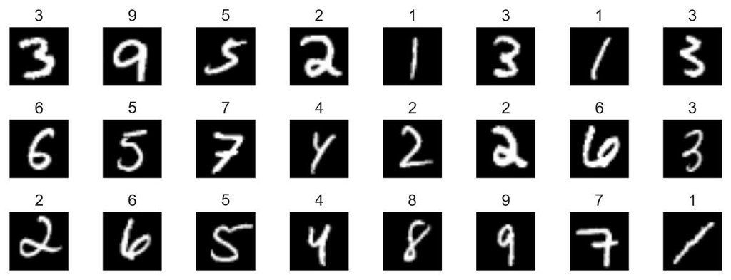

### Input representation

**Input representation** or **feature extraction**

- **“raw” input**

  | pixels | $\boldsymbol{x}^{\intercal}=\left(\begin{array}{cccc} x_{0} & x_{1} & \dots & x_{256}\end{array}\right)$ |
  | --- | --- |
  | linear model | $\boldsymbol{{\color{red}w}}^{\intercal}=\left(\begin{array}{cccc} {\color{red}w_{0}} & {\color{red}w_{1}} & \dots & {\color{red}w}_{{\color{red}256}}\end{array}\right)$ |

- **Feature extraction**: extract useful information

  | *intensity and symmetry* | $\boldsymbol{x}^{\intercal}=\left(\begin{array}{cc} x_{1} & x_{2}\end{array}\right)$ |
  | --- | --- |
  | linear model | $\boldsymbol{{\color{red}w}}^{\intercal}=\left(\begin{array}{cc} {\color{red}w_{1}} & {\color{red}w}_{{\color{red}2}}\end{array}\right)$ |

### Illustration of Features

[figure not shown]

### The Problem with Categorical Data

- Some algorithms can work with categorical data directly.
  - For example, a decision tree can be learned directly from categorical data with no data transform required
- Many machine learning algorithms cannot operate on label data directly.
  - They require all input variables and output variables to be numeric.
- There are two common types of conversion: integer encoding and one-hot encoding

### Integer Encoding

- For categorical variables where no such ordinal relationship exists, the integer encoding is not enough.

[figure not shown]

### One-Hot Encoding

- One-hot encoding ensures that machine learning does not assume that higher numbers are more important.

[figure not shown]

### Classifier Training

- **Select** the learning model for **classifier**, e.g., Perceptron
- **Train** the classifier/model using a training set $\mathcal{D}=\{(\boldsymbol{x}_{1},y_{1}),...,(\boldsymbol{x}_{N},y_{N})\}$

[figure not shown]

## 3.5 Logistic Regression

### A Third Linear Model

$$s=\sum_{i=0}^{d}{\color{red}w_{i}}x_{i}$$

| linear classification | linear regression | logistic regression |
| --- | --- | --- |
| $h(\boldsymbol{x})=sign(s)$ | $h(\boldsymbol{x})=s$ | $h(\boldsymbol{x})=\sigma(s)$ |

[figure not shown]

### The logistic function

- The formula
  $$\sigma(s)=\frac{1}{1+e^{-s}}$$
- The **logistic function** converts a score to a probability
- Properties

$$\sigma(-s)=1-\sigma(s)$$

$$\sigma^{\prime}(s)=\sigma(s)(1-\sigma(s))$$

### Probability Interpretation

- $h(\boldsymbol{x})=\sigma(s)$ can be interpreted as a probability
- For example, prediction of heart attacks
  - Input $\boldsymbol{x}$: cholesterol level, age, weight, etc.
  - The signal $s=\boldsymbol{{\color{red}w}}^{T}\boldsymbol{x}$: risk score
  - $\sigma(s)$: probability of a heart attack

[figure not shown]

### Problem Statement

- The target function $f$ is the probability distribution
  $$f:\mathbb{R}^{D}\to[0,1]$$
- Hypothesis set $h_{\boldsymbol{{\color{red}w}}}(\boldsymbol{x})=\sigma(\boldsymbol{{\color{red}w}}^{T}\boldsymbol{x})$ and the conditional probability
  $$P(y\mid\boldsymbol{x},\boldsymbol{{\color{red}w}})=\left\{ \begin{array}{ccc}
  h_{\boldsymbol{{\color{red}w}}}(\boldsymbol{x}) & \text{for} & y=1\\
  1-h_{\boldsymbol{{\color{red}w}}}(\boldsymbol{x}) & \text{for} & y=0
  \end{array}\right.$$

### Error measure

We define error measurement based on likelihood

- For each $(\boldsymbol{x},y)$, $y$ is generated by probability $h_{\boldsymbol{{\color{red}w}}}(\boldsymbol{x})$.
- Plausible error measure based on **likelihood** of $y$ given $\boldsymbol{x}$ and ${\color{red}\boldsymbol{w}}$
  $$P(y\mid\boldsymbol{x},\boldsymbol{{\color{red}w}})=z^{y}(1-z)^{1-y}$$
  where
  $$z=h_{\boldsymbol{{\color{red}w}}}(\boldsymbol{x})=\sigma(\boldsymbol{{\color{red}w}}^{\intercal}\boldsymbol{x})$$
- Likelihood of $\mathcal{D}=\{(\boldsymbol{x}_{1},y_{1})...(\boldsymbol{x}_{N},y_{N})\}$ given ${\color{red}\boldsymbol{w}}$ is
  $$\prod_{n=1}^{N}P(y_{n}\mid\boldsymbol{x}_{n},\boldsymbol{{\color{red}w}})$$
- **Learning goal**: maximizing likelihood
  $$\begin{array}{ccc}
  & \text{Maximize} & \prod_{n=1}^{N}P(y_{n}\mid\boldsymbol{x}_{n},\boldsymbol{{\color{red}w}})\\
  \Leftrightarrow & \text{Minimize} & -\log\prod_{n=1}^{N}P(y_{n}\mid\boldsymbol{x}_{n},\boldsymbol{{\color{red}w}})\\
  \Leftrightarrow & \text{Minimize} & -\sum_{n=1}^{N}(y_{n}\log z_{n}+(1-y_{n})\log(1-z_{n}))
  \end{array}$$

### Learning Algorithm (Gradient Descent)

1. Initialize the weights (parameters) at $t=0$ $\boldsymbol{{\color{red}w}}_{0}$
2. For $t=1,2,3,...$ do
   1. Compute the outputs $z_{n}$ for each $\boldsymbol{x}_{n}$ ($n=1,...,N$)
      $$\begin{equation}
      z_{n}=\sigma(\boldsymbol{{\color{red}w}}_{t}^{T}\boldsymbol{x}_{n})
      \end{equation}$$
   2. Compute the gradient
      $$\begin{equation}
      \nabla_{{\color{red}\boldsymbol{w}}}E=\frac{1}{N}\sum_{n=1}^{N}\boldsymbol{x}_{n}(z_{n}-y_{n})
      \end{equation}$$
   3. Update the weights
      $$\begin{equation}
      {\color{red}\boldsymbol{w}}_{t+1}=\boldsymbol{{\color{red}w}}_{t}-{\color{green}\eta}\nabla_{{\color{red}\boldsymbol{w}}}E
      \end{equation}$$
      where ${\color{green}\eta}$ is a learning rate (*hyper*-*parameter*)

   Iterate the next step until $\boldsymbol{{\color{red}w}}$ is not changes
3. Return the final weights ${\color{red}\boldsymbol{w}}$

### Learning Rate

- How ${\color{green}\eta}$ affects the algorithm?

[figure not shown]

### Programming Example

```python
import matplotlib.pyplot as plt
import seaborn as sns
sns.set(style="darkgrid")

# Load the example titanic dataset
df = sns.load_dataset("titanic")

# Make a custom palette with gendered colors
pal = dict(male="#6495ED", female="#F08080")

# Show the survival proability as a function of age and sex
g = sns.lmplot(x="age", y="survived", col="sex", hue="sex", data=df, palette=pal, y_jitter=.02, logistic=True, ci=None)
g.set(xlim=(0, 80), ylim=(-.05, 1.05))
plt.show()
```

[figure not shown]

### Evaluation

- Consider two-class problem with two classes $\oplus$ and $\ominus$
- The performance of logistic regression model is based on a threshold $th$

  $$\begin{aligned}
  y\text{ is } \oplus & \text{ if }P(y\mid\boldsymbol{x})\geq th\nonumber \\
  y\text{ is } \ominus & \text{ if }P(y\mid\boldsymbol{x})<th
  \end{aligned}$$
  - High threshold: high specificity, low sensitivity
  - Low threshold: low specificity, high sensitivity
- We should select the best threshold for the trade-off between the cost of *false positives* vs *false negatives*

### ROC Curve

- The receiver operating characteristic ($ROC$) curve is plot which shows the performance of a binary classifier as function of its cut-off threshold.
- It essentially shows the *true positive rate* (*sensitivity*) against the *false positive rate* (1-*specificity*) for various threshold values.
- The area under the curve ($AUC$) is an aggregated measure of performance.

[figure not shown]

### Multi-class classification problems

- **Email foldering/tagging**: Work (1), Friends (2), Family (3), Hobby (4)
- **Medical diagrams**: Not ill, Cold, Flu
- **Weather**: Sunny, Cloudy, Rain, Snow

### Visual of Binary vs Multi-class classification

[figure not shown]

### Approaches

- One-vs-one
- Hierarchical
- **One-vs-all**

### One-vs-all

[figure not shown]

- Class $\circ$ (1):
  $$h^{(1)}(\boldsymbol{x})=P(y=1\mid\boldsymbol{x},\boldsymbol{{\color{red}w}}_{1})$$
- Class $\vartriangle$ (2):
  $$h^{(2)}(\boldsymbol{x})=P(y=2\mid\boldsymbol{x},\boldsymbol{{\color{red}w}}_{2})$$
- Class $\lozenge$ (3):
  $$h^{(3)}(\boldsymbol{x})=P(y=3\mid\boldsymbol{x},\boldsymbol{{\color{red}w}}_{3})$$

**Learning**

- Train a logistic regression classifier $h^{(i)}(\boldsymbol{x})$ for each class $i$ to predict the probability that $y=i$.

**Prediction**

- On a new input $\boldsymbol{x}$, to make a prediction, pick the class $i$ that maximizes
  $$\arg\max_{i}(h^{(i)}(\boldsymbol{x}))$$

### Decision boundaries and decision regions

- Logistic regression for **Iris** dataset

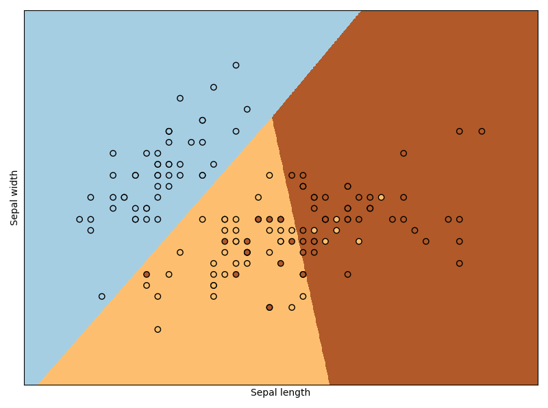

## 3.6 Softmax Regression

### Softmax Regression

**Softmax regression** is a generalization of logistic regression that we can use for multi-class classification

- In Softmax regression, we replace the sigmoid function by the so-called softmax function $\boldsymbol{\phi}(\cdot)=\{\phi_{1},...,\phi_{C}\}$.

### Score function

The **score function** $f$ that maps the raw features to class scores.
$$\boldsymbol{z}=f(\boldsymbol{x};{\color{red}W},{\color{red}\boldsymbol{b}})={\color{red}W}\boldsymbol{x}+{\color{red}\boldsymbol{b}}$$

[figure not shown]

- Use bias trick ${\color{red}W_{0}}={\color{red}\boldsymbol{b}}$ to represent the two parameters ${\color{red}W},{\color{red}\boldsymbol{b}}$ as one
  $$\boldsymbol{z}=f(\boldsymbol{x};{\color{red}W})={\color{red}W}\boldsymbol{x}$$

[figure not shown]

### Softmax function

The **softmax function** converts a score vector $\boldsymbol{z}=(z_{1},...,z_{C})$ to a discrete distribution vector $\boldsymbol{p}=(p_{1},...,p_{C})$
$$p_{i}=P(y=i\mid\boldsymbol{z})=\phi_{i}(\boldsymbol{z})=\frac{e^{z_{i}}}{\sum_{j=1}^{C}e^{z_{j}}},\;i\in[1,...,C]$$
where
$$z_{i}={\color{red}w}_{{\color{red}i0}}+{\color{red}w}_{{\color{red}i1}}x_{1}+...+{\color{red}w}_{{\color{red}iD}}x_{D}={\color{red}\boldsymbol{w}}_{{\color{red}i}}^{\mathbin{\color{red}\intercal}}\boldsymbol{x}$$

[figure not shown]

### Problem Statement

- Given $\mathcal{D}=\{(\boldsymbol{x}_{1},y_{1})...(\boldsymbol{x}_{N},y_{N})\}$ where $y_{n}\in\{1,...,C\}$.
- Denote $\boldsymbol{t}_{n}$ is a **one-hot encoding** of $y_{n}$ (or target discrete distribution)
- **Learning goal**: Find a softmax function $\boldsymbol{\phi}_{{\color{red}W}}(\cdot)=\{\phi_{1},...,\phi_{C}\}$ that minimize
  $$\arg\min_{{\color{red}W}}E(\boldsymbol{\phi}_{{\color{red}W}})=\arg\min_{{\color{red}W}}\sum_{n=1}^{N}CE(\boldsymbol{p}_{n},\boldsymbol{t}_{n})$$

### Cross Entropy

**Cross-entropy** (CE) is a measure of the difference between two probability distributions. The cross-entropy between a “true” distribution $\boldsymbol{t}=(t_{1},...,t_{C})$ and an estimated distribution $\boldsymbol{p}=(p_{1},...,p_{C})$ is defined as
$$CE(\boldsymbol{p},\boldsymbol{t})=-\sum_{i=1}^{C}t_{i}\log p_{i}$$

[figure not shown]

$$\left.\begin{array}{c}
\boldsymbol{p}=(0.1,0.2,0.4,0.2,0.1)\\
\boldsymbol{t}=(0.2,0.4,0.2,0.1,0.1)
\end{array}\right\} \to CE(\boldsymbol{p},\boldsymbol{t})=1.678$$

- $CE>0$
- $CE(\boldsymbol{p},\boldsymbol{t})\neq CE(\boldsymbol{t},\boldsymbol{p})$
- $CE$ minimize if $p_{i}=t_{i},\forall i$

### MSE

**Mean squared error** (MSE) is a measure of the average of the squares of the errors.
$$MSE(\boldsymbol{p},\boldsymbol{t})=\frac{1}{C}\sum_{i=1}^{C}(p_{i}-t_{i})^{2}$$

- $MSE\geq0$
- $MSE(\boldsymbol{p},\boldsymbol{t})=MSE(\boldsymbol{t},\boldsymbol{p})$
- $MSE=0$ if $p_{i}=t_{i},\forall i$

### Cross Entropy vs. MSE

- Consider three “true” binary distributions $\boldsymbol{p}=(0.1,0.9),(0.5,0.5)$ and $(0.8,0.2)$

[figure not shown]

### Learning Algorithm

1. Initialize the weights ${\color{red}W}_{0}$ (parameters) at $t=0$
2. For $t=1,2,3,...$ do
   1. Compute the ouput distribution $\boldsymbol{p}_{n}$ for each $\boldsymbol{x}_{n}$ ($n=1...N$)
      $$\begin{equation}
      \boldsymbol{p}_{n}=softmax({\color{red}W}_{t}\boldsymbol{x}_{n})
      \end{equation}$$
   2. Compute the gradient
      $$\begin{equation}
      \nabla_{{\color{red}W}}E=\frac{1}{N}\sum_{n=1}^{N}(\boldsymbol{p}_{n}-\boldsymbol{t}_{n})\boldsymbol{x}_{n}^{\intercal}
      \end{equation}$$
   3. Update the weights
      $$\begin{equation}
      {\color{red}{\color{red}W}}_{t+1}={\color{red}W}_{t}-{\color{green}\eta}\nabla_{{\color{red}W}}E
      \end{equation}$$

   Iterate the next step until ${\color{red}W}$ is not change
3. Return the final weights ${\color{red}W}$

### Example

- Softmax regression for **Iris** dataset

[figure not shown]

## 3.7 Capacity, Overfitting and Underfitting

### Model Capacity

**Capacity** is model complexity.

The most common ways to estimate the capacity of a model:

- VC dimension
- The number of parameters
- The norm of parameters

[figure not shown]

### Model vs. Data

Data is divided into three sets: **training set**, **validation set** and **test set**.

Models can be too limited. We can’t find a function that fits the data well. This is called **underfitting**.

Models can also be too rich. We don’t just model the data, but also the underlying noise. This is called **overfitting**.

- Given the data set $\mathcal{D}=\{(x_{1},y_{1}),...(x_{10},y_{10})\}$ shown in the following figure, find the best regression function to the data

[figure not shown]

- Consider the simple hypothesis set
  $$\mathcal{H}_{1}=\{h\mid y=h(x)={\color{red}w_{0}}+{\color{red}w}_{{\color{red}1}}x\}$$

[figure not shown]

- Consider the hypothesis set
  $$\mathcal{H}_{3}=\{h\mid y=h(x)={\color{red}w_{0}}+{\color{red}w}_{{\color{red}1}}x+{\color{red}w_{2}}x^{2}+{\color{red}w}_{{\color{red}3}}x^{3}\}$$
  (note that $\mathcal{H}_{1}\subset\mathcal{H}_{3}$)

[figure not shown]

- Consider the hypothesis set
  $$\mathcal{H}_{9}=\{h\mid y=h(x)={\color{red}w}_{{\color{red}0}}+{\color{red}w}_{{\color{red}1}}x+{\color{red}w}_{{\color{red}2}}x^{2}+...+{\color{red}w}_{{\color{red}9}}x^{9}\}$$
  (note that $\mathcal{H}_{1}\subset\mathcal{H}_{3}\subset\mathcal{H}_{9}$)

[figure not shown]

Which one

- Under-fitting
- Over-fitting
- **Appropriate fitting**

[figure not shown]

|  | $M=1$ | $M=3$ | $M=9$ |
| --- | --- | --- | --- |
| ${\color{red}w_{0}}$ | 0.82 | 0.31 | 0.35 |
| ${\color{red}w_{1}}$ | -1.27 | 7.99 | 232.37 |
| ${\color{red}w_{2}}$ |  | -25.43 | -5321.83 |
| ${\color{red}w_{3}}$ |  | 17.37 | 48568.31 |
| ${\color{red}w_{4}}$ |  |  | -231639.30 |
| ${\color{red}w_{5}}$ |  |  | 640042.26 |
| ${\color{red}w_{6}}$ |  |  | -1061800.52 |
| ${\color{red}w_{7}}$ |  |  | 1042400.18 |
| ${\color{red}w_{8}}$ |  |  | -557682.99 |
| ${\color{red}w_{9}}$ |  |  | 125201.43 |

### Model Performance

[figure not shown]

### What happen if increasing $N$

[figure not shown]

### Errors in Learning Model

- **Bias errors**: error due to assumption in the model
  - High bias to signify underfitting
- **Variance errors**: It measures the variability in the results given by model when the dataset is changed
  - High variance to signify overfitting

$$\text{Expected error}=\text{Bias}+\text{Variance}+\text{Irreducible Error}$$

Given a learning model $\left\langle \mathcal{H},\mathcal{A}\right\rangle$, we define the “average” hypothesis $\overline{g}(x)$
$$\overline{g}(x)=\mathbb{E}_{\mathcal{D}}\left[g_{\mathcal{D}}(x)\right]$$
where $g_{\mathcal{D}}(x)$ is the “**best**” hypothesis given the data set $\mathcal{D}$

- Bias of learning model
  $$\text{Bias}=\mathbb{E}_{x}\left[\left(\overline{g}(x)-f(x)\right)^{2}\right]$$
  where $f(x)$ is the “**truth**” function
- Variance of learning model
  $$\text{Variance}=\mathbb{E}_{x}\left[\mathbb{E}_{\mathcal{D}}\left[(g_{\mathcal{D}}(x)-\overline{g}(x))^{2}\right]\right]$$

[figure not shown]

- Given many independent data sets $\mathcal{D}_{1},\mathcal{D}_{2},...,\mathcal{D}_{K}$, we can estimate $\overline{g}(x)$ by
  $$\overline{g}(x)\approx\frac{1}{K}\sum_{i=1}^{K}g_{\mathcal{D}_{i}}(x)$$

### Example: two learning models

- Consider a target function sine
  $$\begin{array}{llccc}
  f & : & [-1,1] & \to & \mathbb{R}\\
  & & x & \to & \sin(\pi x)
  \end{array}$$
- We generate 100 data sets $\left\{ \mathcal{D}_{i}\right\} ,i=1,...,100$, each containing $N=2$ data points, independently from the sinusoidal curve $f(x)=\sin(\pi x)$. For each data set $\mathcal{D}_{i}$, we fit the data using one of two models
  - $\mathcal{H}_{0}$: set of all lines of the form $h(x)={\color{red}b}$
  - $\mathcal{H}_{1}$: set of all lines of the form $h(x)={\color{red}a}x+{\color{red}b}$
  - Note that $\mathcal{H}_{0}\subset\mathcal{H}_{1}$
- Given a data set $\mathcal{D}_{i}=\{(x_{1},y_{1}),(x_{2},y_{2})\}$.
  - For $\mathcal{H}_{0}$, we choose the constant hypothesis that best fits the data (the horizontal line at the midpoint, $b=(y_{1}+y_{2})/2$).
  - For $\mathcal{H}_{1}$, we choose the line that passes through the two data points $(x_{1},y_{1})$ and $(x_{2},y_{2})$.

[figure not shown]

- Repeating this process with 100 data sets $\left\{ \mathcal{D}_{i}\right\} ,i=1,...,100$,

[figure not shown]

- The bias-variance for each learning model

[figure not shown]

### Generalization and Capacity

The criteria determining how well a machine learning model will perform:

1. Make the training error small.
2. Make the gap between training and test (generalization) error small.

[figure not shown]

### Regularization

**Regularization** is any modification we make to a learning model that is intended to reduce its generalization error but not its training error.

[figure not shown]

### Addressing

| **High bias** | **High variance** |
| --- | --- |
| Obtain more features | Decrease number of features |
| Decrease regularization ${\color{green}\lambda}$ | Increase regularization ${\color{green}\lambda}$ |
| Extend model | Obtain more data |
| Train longer | Stop early |
| New model architecture | New model architecture |

### Regularization for Linear Regression

- Using regularized $MSE_{train}$ for linear regression
  $$\boldsymbol{{\color{red}w}}=\arg\min_{\boldsymbol{{\color{red}w}}}\left[MSE_{train}+{\color{green}\lambda}\left(\frac{1}{N}\boldsymbol{{\color{red}w}}^{T}\boldsymbol{{\color{red}w}}\right)\right]$$
  where ${\color{green}\lambda}$ is the regularization coefficient (*hyper*-*parameter*) that controls the relative importance of the data-dependent error $MSE_{train}$ and the regularization term ${\color{green}\lambda}\left(\frac{1}{N}\boldsymbol{{\color{red}w}}^{T}\boldsymbol{{\color{red}w}}\right)$
- Solving for $\boldsymbol{{\color{red}w}}$, we obtain
  $$\boldsymbol{{\color{red}w}}=(\boldsymbol{X}^{\intercal}\boldsymbol{X}+{\color{green}\lambda}\boldsymbol{I})^{-1}\boldsymbol{X}^{\intercal}\boldsymbol{y}$$

### Tradeoff of Regularization

#### Example: one learning model

- Consider a target function sine
  $$\begin{array}{llccc}
  f & : & [-1,1] & \to & \mathbb{R}\\
  & & x & \to & \sin(2\pi x)
  \end{array}$$
- We generate 100 data sets $\left\{ \mathcal{D}_{i}\right\} ,i=1,...,100$, each containing $N=25$ data points, independently from the sinusoidal curve $f(x)=\sin(2\pi x)$. For each data set $\mathcal{D}_{i}$, we fit a model with 24 Gaussian basis functions by minimizing the regularized error function
- Illustration of the dependence of bias and variance on model regularization coefficient

[figure not shown]

- Summary of the dependence of bias and variance on model regularization coefficient

[figure not shown]

## 3.8 References

[video not shown]